# racoon_clip processing report

Melina Klostermann

07 January, 2026

# 1 Overview of steps performed

**racoon_clip crosslinks** was used.

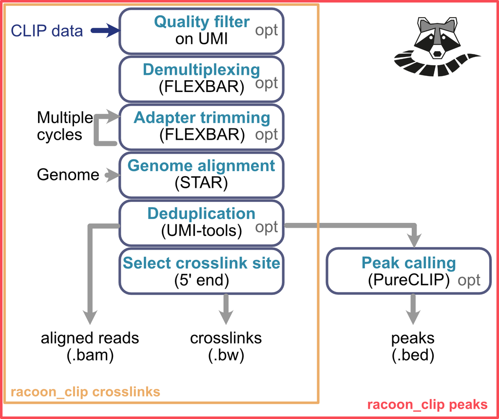

# 2 Configurations

Here is a summary of the settings you have chosen for this analysis.

## 2.1 Input files

Input files and reference data used in the analysis

|  | Input |
| --- | --- |
| infiles | /home/mek24iv/racoon_devel/racoon_clip/example_data/example_eCLIP_ENCODE/test_eCLIP_ENC_s1.chr21.fastq /home/mek24iv/example_data/example_eCLIP_ENCODE/test_eCLIP_ENC_s2.chr21.fastq |
| barcodes_fasta |  |
| gtf | /home/mek24iv/racoon_devel/racoon_clip/example_data/example_annotation_human_chr21/test_annotation_chr21.gtf |
| genome_fasta | /home/mek24iv/racoon_devel/racoon_clip/example_data/example_annotation_human_chr21/test_annotation_chr21.fa |
| fastqScreen_config |  |

## 2.2 Options

Analysis workflow options and settings

|  | Option |
| --- | --- |
| workflow_type | NA |
| demultiplex | FALSE |
| adapter_trimming | TRUE |
| trim3 | FALSE |
| quality_filter_barcodes | FALSE |
| encode | FALSE |
| deduplicate | TRUE |
| fastqScreen | FALSE |

## 2.3 Barcode settings

Barcode and UMI configuration parameters

|  | Setting |
| --- | --- |
| barcodeLength |  |
| minBaseQuality | 10 |
| umi1_len | 0 |
| umi2_len | 0 |
| total_barcode_len | 0 |
| samples | test_eCLIP_ENC_s1.chr21 test_eCLIP_ENC_s2.chr21 |
| encode | FALSE |
| encode_umi_length | 10 |

## 2.4 Read filter

Read length filtering parameters

|  | Setting |
| --- | --- |
| min_read_length | 15 |

## 2.5 Peakcalling

Peak calling parameters for Pureclip

|  | Setting |
| --- | --- |
| morePureclipParameters |  |

## 2.6 Alignment setting (STAR)

STAR alignment parameters and settings

|  | Setting |
| --- | --- |
| read_length | 45 |
| outFilterMismatchNoverReadLmax | 0.04 |
| outFilterMismatchNmax | 999 |
| outFilterMultimapNmax | 1 |
| outReadsUnmapped | Fastx |
| outSJfilterReads | Unique |
| moreSTARParameters |  |

## 2.7 Experimental groups

Experimental groups and sample assignments

| Group | Sample |
| --- | --- |
| test_eCLIP_ENC | test_eCLIP_ENC_s1.chr21 |
| test_eCLIP_ENC | test_eCLIP_ENC_s2.chr21 |

# 3 Input sequencing files

Input sequencing files summary

| Sample | Total.Sequences | Sequence.Length |
| --- | --- | --- |
| test_eCLIP_ENC_s1.chr21 | 1,100 | 45 |
| test_eCLIP_ENC_s2.chr21 | 1,100 | 45 |

# 4 Quality control of raw files

Initial quality control of the raw sequencing file is performed with FastQC. Here you can see the sequencing quality and content per base.

## 4.1 Quality scores across all bases

### test_eCLIP_s1.chr21

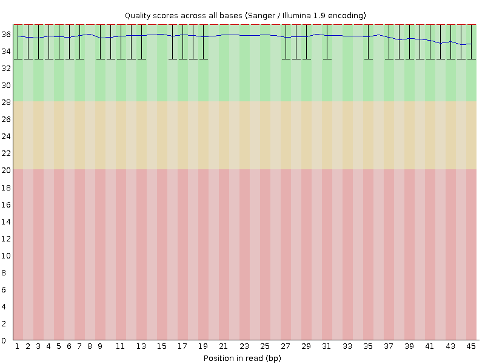

### test_eCLIP_s2.chr21

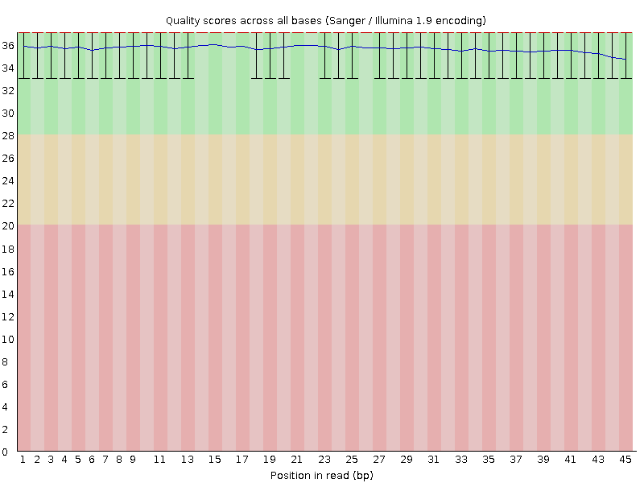

## 4.2 Sequence content over all bases

### test_eCLIP_s1.chr21

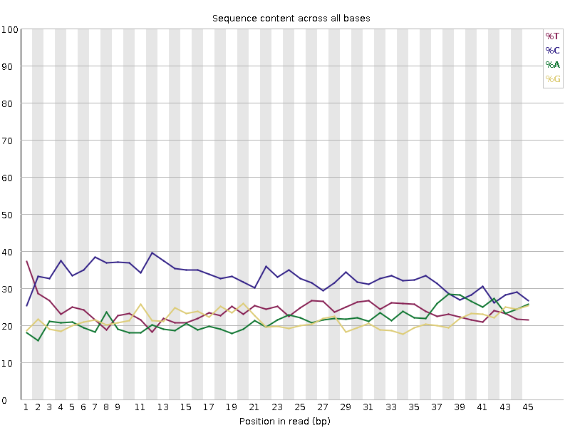

### test_eCLIP_s2.chr21

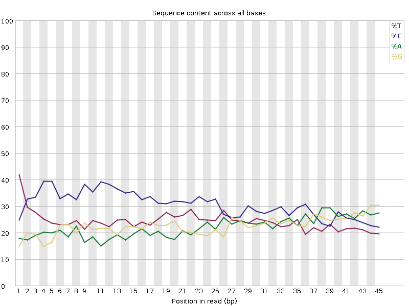

**Note:** In CLIP-seq data, it is normal to observe an enrichment of thymine (T) nucleotides at the crosslink position, which occurs immediately following the barcode and UMI sequences. This T-enrichment is a characteristic signature of UV-induced crosslinking.

# 5 Adapter trimming

**Adapter Content Detection and Trimming:**  
If FastQC reports “No adapter content found” in the raw files, this indicates that adapter sequences were not detected by FastQC’s automated detection. However, adapter trimming is still performed using FLEXBAR with the adapter sequences specified in your configuration file. If no file is provied, a default file is used, which contains standard Illumina and eCLIP adapters.

UMIs are written into the read header with (`--umi-tags`). (If the data is from ENCODE, UMIs are already removed from the read and written to the beginning of the header. As umi-tools dedup, which is used here for deduplication, expects the UMI to be at the end of the read, encode: True can be specified to move the UMI from the beginning of the read header to the end (see configurations).)

Read counts through quality filtering and adapter trimming steps

[output not shown]

[figure not shown]

## 5.1 Adapter content before trimming

Position of adapters found in the reads. If adapters are found early in the reads, this indicates over digestion of the samples.

**No adapter content was detected in the raw files.**

## 5.2 Adapter content after trimming

**Trimming successful, no adapter contents left.**

# 6 Alignment

The genome annotation is indexed using STAR `--runMode genomeGenerate`. The merged file of chimeric reads is then aligned to the genome annotation using STAR `--runMode alignReads`. For STAR settings, see Configurations. The resulting bam files are indexed using samtools index.

STAR alignment statistics for all samples

|  | test_eCLIP_ENC_s1.chr21 | test_eCLIP_ENC_s2.chr21 |
| --- | --- | --- |
| Number of input reads | 1100 | 1100 |
| Uniquely mapped reads number | 1079 | 1056 |
| Uniquely mapped reads % | 98.09% | 96.00% |
| Number of reads mapped to multiple loci | 0 | 0 |
| % of reads mapped to multiple loci | 0.00% | 0.00% |
| Number of reads mapped to too many loci | 20 | 41 |
| % of reads mapped to too many loci | 1.82% | 3.73% |
| Number of reads unmapped: too many mismatches | 1 | 3 |
| % of reads unmapped: too many mismatches | 0.09% | 0.27% |
| Number of reads unmapped: too short | 0 | 0 |
| % of reads unmapped: too short | 0.00% | 0.00% |
| Number of reads unmapped: other | 0 | 0 |
| % of reads unmapped: other | 0.00% | 0.00% |

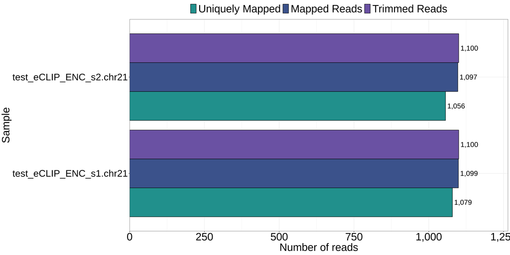

# 7 Deduplication

Reads are deduplicated with umi_tools dedup `--extract-umi-method read_id --method unique`.

Read counts from raw input through alignment and UMI-based deduplication

| Sample | Uniquely Mapped Reads | Deduplicated Reads |
| --- | --- | --- |
| test_eCLIP_ENC_s1.chr21 | 1,079 | 981 |
| test_eCLIP_ENC_s2.chr21 | 1,056 | 962 |

# 8 Obtaining crosslinks

The (deduplicated) bam files are then converted to bed files using bedtools bamtobed. The reads are shifted 1nt upstream (5’ direction) with bedtools shift -m 1 -p -1 because the UV crosslink should be positioned 1nt earlier. To allow visualisation in a genome browser, the 1nt crosslink bed file is also converted to a .bigWig file using bedGraphToBigWig. These bigWig files are then merged with bigWigMerge by the experiment groups specified by the user.

Crosslink identification and nucleotide-level resolution statistics

|  | Uniquely mapped reads | Crosslink events (deduplicated reads) | Crosslinked nucleotides | Mean crosslink events per crosslinked nucleotide |
| --- | --- | --- | --- | --- |
| test_eCLIP_ENC_s1.chr21 | 1,079 | 981 | 748 | 1.31 |
| test_eCLIP_ENC_s2.chr21 | 1,056 | 962 | 774 | 1.24 |

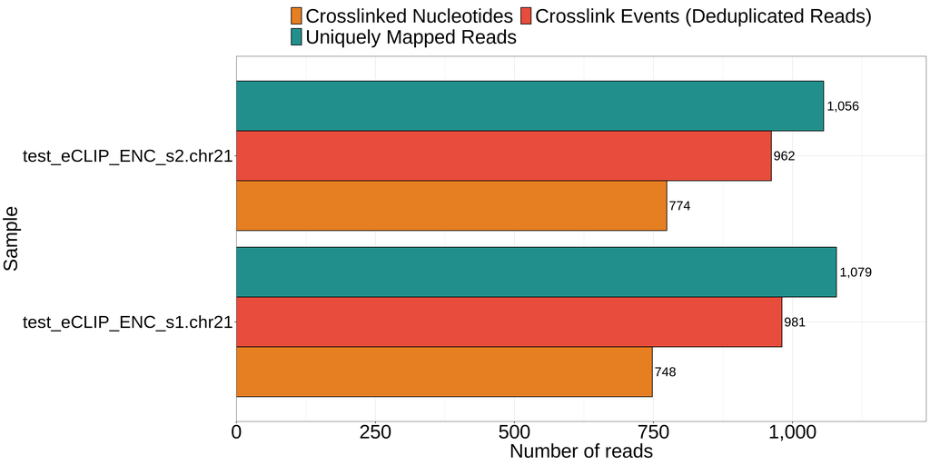